# Making cumulative plots - example

Timothy Johnstone

Here is a quick tutorial on how to make a cumulative plot in R.

I’ll assume you’ve imported your data into a data frame as usual. For the purposes of this tutorial, we will use a sample dataset built into R which contains EU Stock market data for 4 different indices

Let’s take a look at that dataset:

```r
head(EuStockMarkets)
```

```
##          DAX    SMI    CAC   FTSE
## [1,] 1628.75 1678.1 1772.8 2443.6
## [2,] 1613.63 1688.5 1750.5 2460.2
## [3,] 1606.51 1678.6 1718.0 2448.2
## [4,] 1621.04 1684.1 1708.1 2470.4
## [5,] 1618.16 1686.6 1723.1 2484.7
## [6,] 1610.61 1671.6 1714.3 2466.8
```

For cumulative plotting, the key function we use is ecdf(). This calculates the empirical cumulative distribution function for a given set of input numbers. More help can be found by typing **?ecdf**

To give you an idea of what the plot output looks like for this function, let’s try a simple single-set plot looking at the DAX stock index:

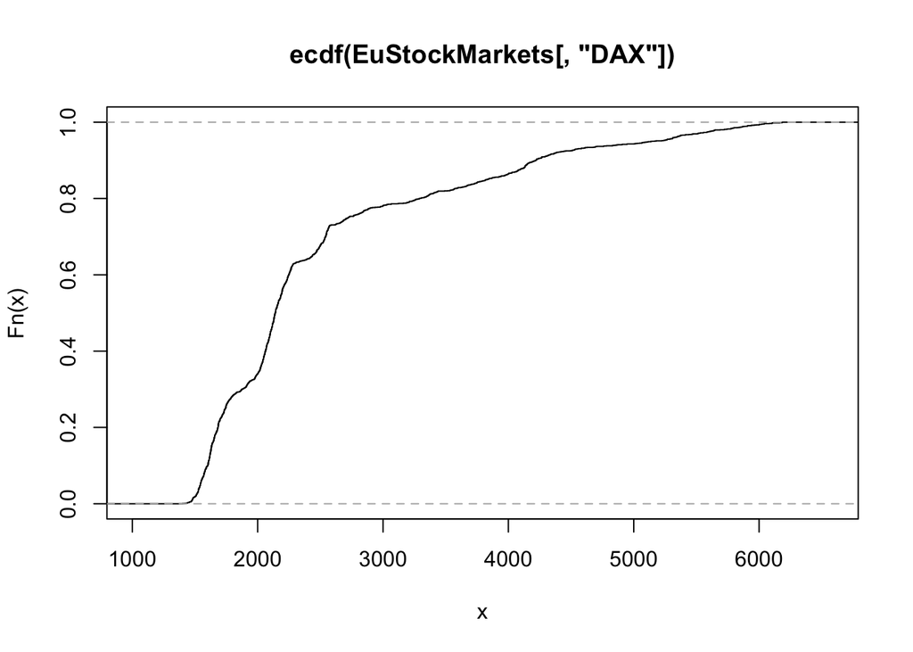

```r
plot(ecdf(EuStockMarkets[,"DAX"]))
```

You will notice this gives a nice looking cumulative plot with smooth lines.

If your dataset is smaller, the plot might default to a more stepwise look rather than smooth lines. These can be changed in the plotting parameters. For example, using another smaller dataframe with flower characteristics:

```r
head(iris)
```

```
##   Sepal.Length Sepal.Width Petal.Length Petal.Width Species
## 1          5.1         3.5          1.4         0.2  setosa
## 2          4.9         3.0          1.4         0.2  setosa
## 3          4.7         3.2          1.3         0.2  setosa
## 4          4.6         3.1          1.5         0.2  setosa
## 5          5.0         3.6          1.4         0.2  setosa
## 6          5.4         3.9          1.7         0.4  setosa
```

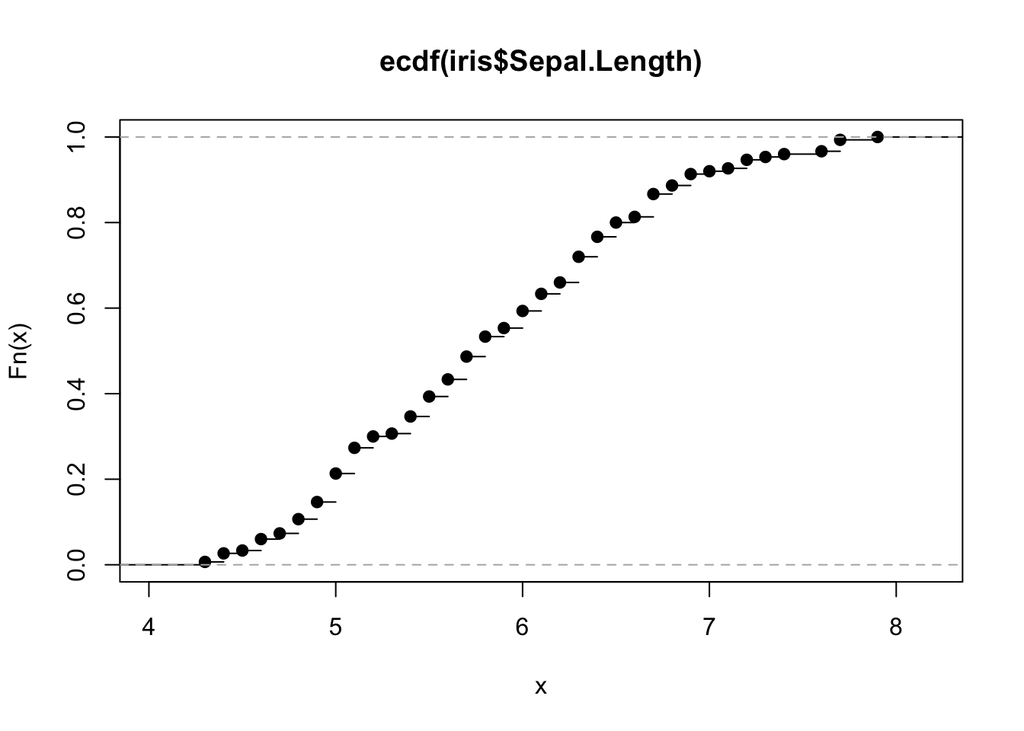

```r
plot(ecdf(iris$Sepal.Length))
```

We can adjust the plot to be more visually pleasing by resizing the points to be tiny

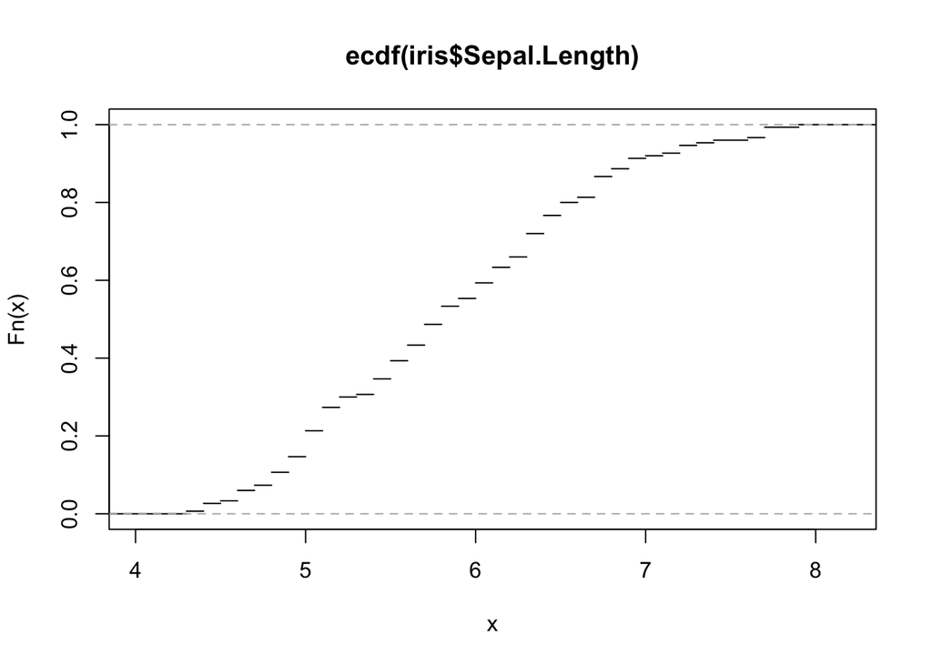

```r
plot(ecdf(iris$Sepal.Length),
     cex=0)
```

What if we want to break down different sets and compare them? I’ll give an example with both datasets. The important thing to remember is to size the x axis on the first **plot** call so that all the datasets will be fully displayed, otherwise the plot will default just to fit that first set.

Here is the plot with the tiny iris dataset, this time comparing different species

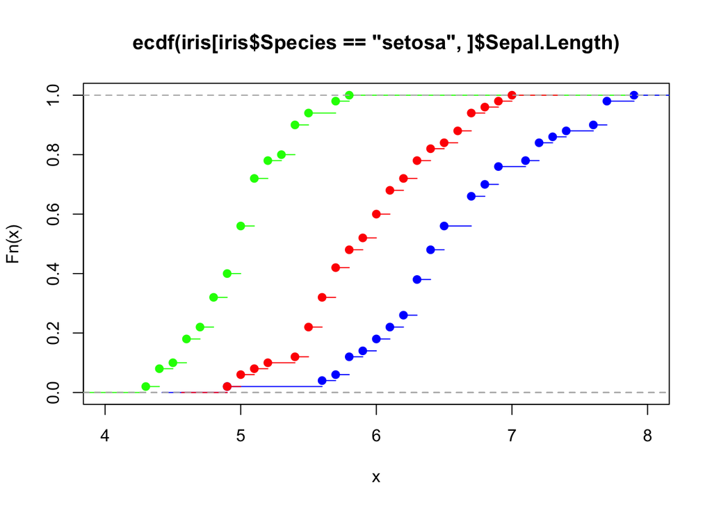

```r
plot(ecdf(iris[iris$Species=="setosa",]$Sepal.Length),
     xlim=c(4,8),
     col="green")
lines(ecdf(iris[iris$Species=="virginica",]$Sepal.Length),
      col="blue")
lines(ecdf(iris[iris$Species=="versicolor",]$Sepal.Length),
      col="red")
```

Of course, these datasets are small (only 50 observations per species) and not pretty to look at. Let’s try it again with the stock exchange data

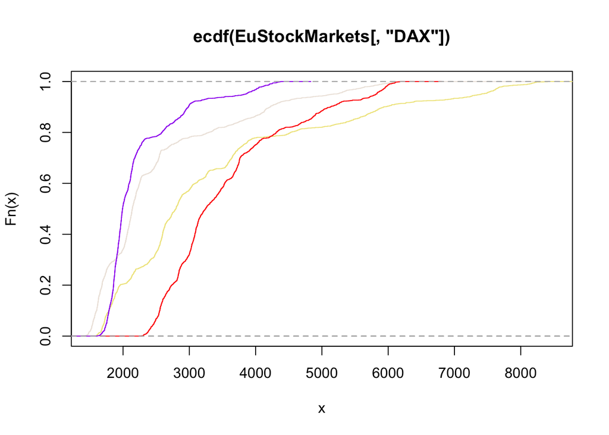

```r
plot(ecdf(EuStockMarkets[,"DAX"]),
     xlim=c(1500,8500),
     col="seashell2")
lines(ecdf(EuStockMarkets[,"SMI"]),
     col="khaki")
lines(ecdf(EuStockMarkets[,"CAC"]),
     col="purple")
lines(ecdf(EuStockMarkets[,"FTSE"]),
     col="red")
```

We can play with other parameters too for a more complete plot. For example, **pty** will force a plot to be square, and we can label the axes and plot using **xlab** and **ylab** and **main**. We also add a legend.

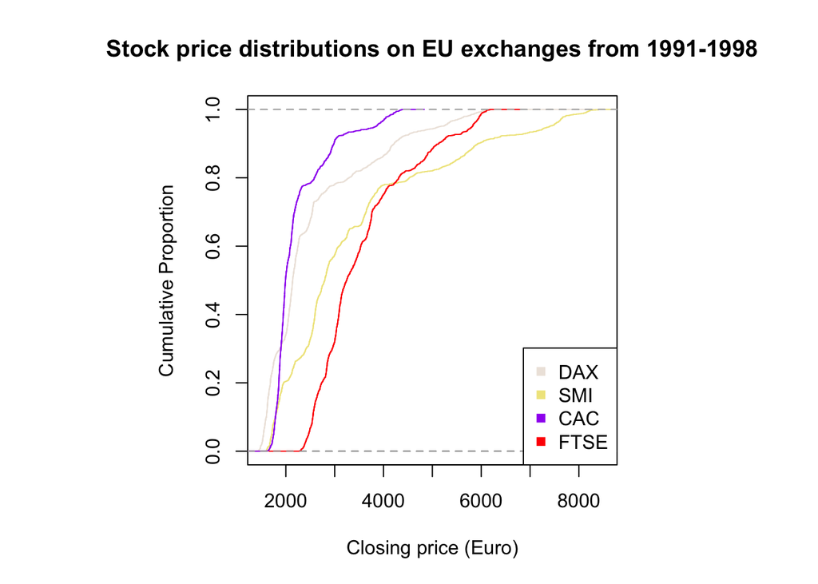

```r
par(pty='s')  # force the plot to be square before we start

plot(ecdf(EuStockMarkets[,"DAX"]),
     xlim=c(1500,8500),
     xlab="Closing price (Euro)",
     ylab="Cumulative Proportion",
     main="Stock price distributions on EU exchanges from 1991-1998",
     col="seashell2")
lines(ecdf(EuStockMarkets[,"SMI"]),
     col="khaki")
lines(ecdf(EuStockMarkets[,"CAC"]),
     col="purple")
lines(ecdf(EuStockMarkets[,"FTSE"]),
     col="red")

legend('bottomright',
       legend=c("DAX","SMI","CAC","FTSE"),  # text in the legend
       col=c("seashell2","khaki","purple","red"),  # point colors
       pch=15)  # specify the point type to be a square
```